# Assignment 5

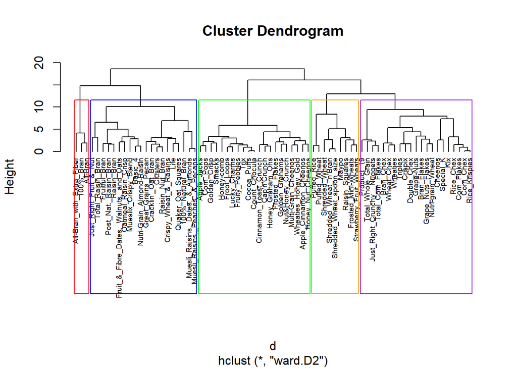

```r
plot(hccluster, cex=0.6, hang=-1)#Plot the obtained dendrogram
rect.hclust(hccluster, k=5, border=c("red", "blue", "green", "orange", "purple"))#to differentiate
```

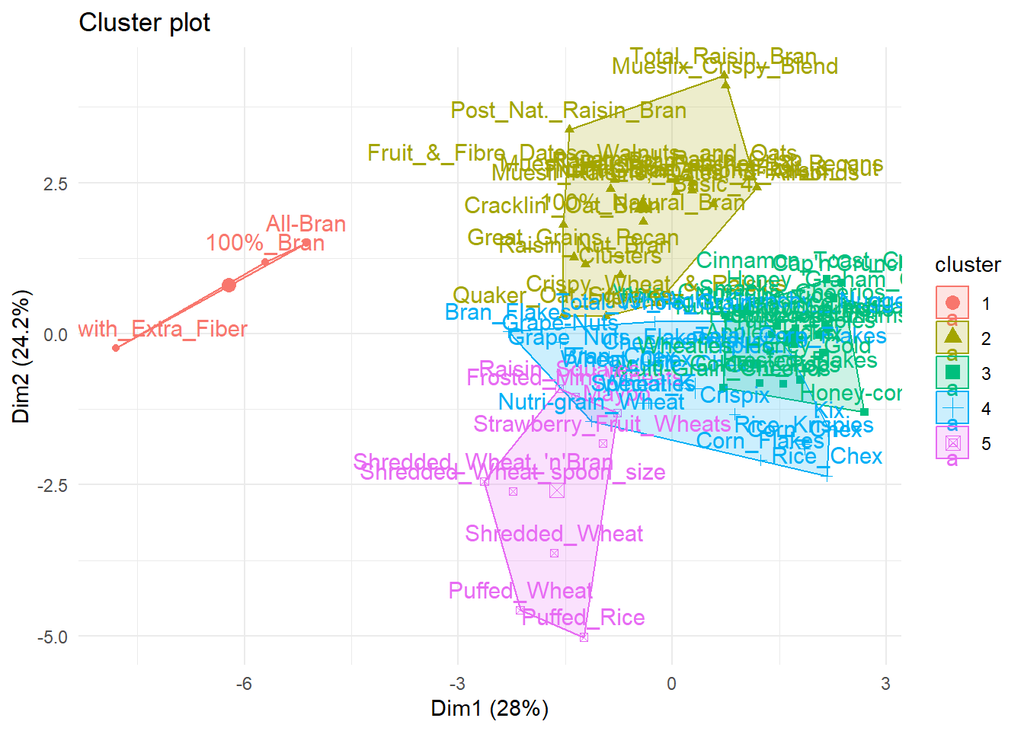

```r
# fviz_cluster function to visualize the clusters
fviz_cluster(list(data = mydata, cluster = hccluster_5, repel = TRUE)) +
  theme_minimal()
```

#Cluster assignment

```r
membership_5<-cutree(hccluster, k=5)
head(membership_5)
```

```
##                 100%_Bran         100%_Natural_Bran                  All-Bran
##                         1                         2                         1
## All-Bran_with_Extra_Fiber   Apple_Cinnamon_Cheerios               Apple_Jacks
##                         1                         3                         3
```

#Centroid (mean value of each attribute)

```r
hccentroid_5<-data.frame(aggregate(scaledmydata,by=list(clusters=membership_5),mean))
hccentroid_5
```

```
##   clusters   calories     protein        fat      sodium       fiber      carbo
## 1        1 -2.2018711  1.38174776 -0.3310734  0.17279012  3.64131237 -2.0718749
## 2        2  0.8553248  0.59163927  0.9435592 -0.08898011  0.38141771 -0.2003584
## 3        3  0.1978117 -0.91996886  0.0000000  0.12101140 -0.66198437 -0.5423583
## 4        4 -0.1621407  0.18662567 -0.4729620  0.77112209 -0.21003997  0.9626860
## 5        5 -1.2499969 -0.06420242 -0.8828625 -1.94150793 -0.02664224  0.1551013
##       sugars     potass    vitamins      shelf     weight       cups     rating
## 1 -0.7894824  2.9837813 -0.18184220  0.9419715 -0.2008324 -1.8452553  2.2426479
## 2  0.5143002  0.7475659  0.09849786  0.8217889  0.9235649 -0.5477863 -0.2928786
## 3  0.9583619 -0.7415648 -0.18184220 -0.6604628 -0.2008324  0.2779676 -0.9636465
## 4 -0.8659505 -0.3485391  0.45893508 -0.1453946 -0.2008324  0.4577648  0.2916795
## 5 -1.0953551 -0.1122758 -0.80482011 -0.2598542 -1.0482044  0.1156788  1.4712151
```

#Q3. Comment on the structure of the clusters and on their stability. Hint: To check stability, partition the data and see how well clusters formed based on one part apply to the other part. To do this: ● Cluster partition A ● Use the cluster centroids from A to assign each record in partition B (each record is assigned to the cluster with the closest centroid). ● Assess how consistent the cluster assignments are compared to the assignments based on all the data.

#Answer: Partition A (70%) was used to compute cluster centroids, and Partition B (30%) was assigned to the closest cluster using Euclidean distance. All assignments matched the original clusters, with an ARI of 1, showing that the clustering solution is highly stable and consistent.

Partition A (70%) and B (30%)

```r
mydata_hc5<-cbind(scaledmydata, hccluster_5)
nrow(mydata_hc5)
```

```
## [1] 74
```

```r
subsetA<-data.frame(mydata_hc5[c(1:51),])
head(subsetA)
```

```
##                             calories    protein        fat     sodium
## 100%_Bran                 -1.8659155  1.3817478  0.0000000 -0.3910227
## 100%_Natural_Bran          0.6537514  0.4522084  3.9728810 -1.7804186
## All-Bran                  -1.8659155  1.3817478  0.0000000  1.1795987
## All-Bran_with_Extra_Fiber -2.8737823  1.3817478 -0.9932203 -0.2702057
## Apple_Cinnamon_Cheerios    0.1498180 -0.4773310  0.9932203  0.2130625
## Apple_Jacks                0.1498180 -0.4773310 -0.9932203 -0.4514312
##                                 fiber      carbo     sugars     potass
## 100%_Bran                  3.22866747 -2.5001396 -0.2542051  2.5605229
## 100%_Natural_Bran         -0.07249167 -1.7292632  0.2046041  0.5147738
## All-Bran                   2.81602258 -1.9862220 -0.4836096  3.1248675
## All-Bran_with_Extra_Fiber  4.87924705 -1.7292632 -1.6306324  3.2659536
## Apple_Cinnamon_Cheerios   -0.27881412 -1.0868662  0.6634132 -0.4022862
## Apple_Jacks               -0.48513656 -0.9583868  1.5810314 -0.9666308
##                             vitamins      shelf     weight       cups
## 100%_Bran                 -0.1818422  0.9419715 -0.2008324 -2.0856582
## 100%_Natural_Bran         -1.3032024  0.9419715 -0.2008324  0.7567534
## All-Bran                  -0.1818422  0.9419715 -0.2008324 -2.0856582
## All-Bran_with_Extra_Fiber -0.1818422  0.9419715 -0.2008324 -1.3644493
## Apple_Cinnamon_Cheerios   -0.1818422 -1.4616799 -0.2008324 -0.3038480
## Apple_Jacks               -0.1818422 -0.2598542 -0.2008324  0.7567534
##                               rating hccluster_5
## 100%_Bran                  1.8549038           1
## 100%_Natural_Bran         -0.5977113           2
## All-Bran                   1.2151965           1
## All-Bran_with_Extra_Fiber  3.6578436           1
## Apple_Cinnamon_Cheerios   -0.9165248           3
## Apple_Jacks               -0.6553998           3
```

```r
subsetB<-data.frame(mydata_hc5[c(52:74),])
head(subsetB)
```

```
##                      calories    protein        fat     sodium       fiber
## Product_19         -0.3541153  0.4522084 -0.9932203  1.9045009 -0.48513656
## Puffed_Rice        -2.8737823 -1.4068705 -0.9932203 -1.9616441 -0.89778146
## Puffed_Wheat       -2.8737823 -0.4773310 -0.9932203 -1.9616441 -0.48513656
## Quaker_Oat_Squares -0.3541153  1.3817478  0.0000000 -0.3306142 -0.07249167
## Raisin_Bran         0.6537514  0.4522084  0.0000000  0.5755136  1.16544301
## Raisin_Nut_Bran    -0.3541153  0.4522084  0.9932203 -0.2702057  0.13383078
##                         carbo     sugars     potass   vitamins      shelf
## Product_19          1.3542423 -0.9424187 -0.7550015  3.1822385  0.9419715
## Puffed_Rice        -0.4444693 -1.6306324 -1.1782600 -1.3032024  0.9419715
## Puffed_Wheat       -1.2153456 -1.6306324 -0.6844585 -1.3032024  0.9419715
## Quaker_Oat_Squares -0.1875105 -0.2542051  0.1620584 -0.1818422  0.9419715
## Raisin_Bran        -0.1875105  1.1222223  1.9961783 -0.1818422 -0.2598542
## Raisin_Nut_Bran    -1.0868662  0.2046041  0.5853168 -0.1818422  0.9419715
##                        weight       cups      rating hccluster_5
## Product_19         -0.2008324  0.7567534 -0.06186866           4
## Puffed_Rice        -3.4599552  0.7567534  1.31001152           5
## Puffed_Wheat       -3.4599552  0.7567534  1.47030646           5
## Quaker_Oat_Squares -0.2008324 -1.3644493  0.50878106           2
## Raisin_Bran         1.9501886 -0.3038480 -0.22179377           2
## Raisin_Nut_Bran    -0.2008324 -1.3644493 -0.19014120           2
```

```r
#Centroid (subsetA)
subsetA_centroid<-data.frame(aggregate(subsetA,by=list(clusters=subsetA$hccluster_5),mean))
View(subsetA_centroid)

reference<-subsetA_centroid[,-1]
reference<-reference[,-14]
View(reference)
input<-subsetB[,-14]
View(input)

dists <- pdist(input, reference) #Measure how far each record is from the centroid of each cluster using Euclidean distance
as.matrix(dists)
```

```
##           [,1]     [,2]      [,3]     [,4]     [,5]
##  [1,] 8.595437 5.534810 5.3221669 3.648443 5.653354
##  [2,] 8.603699 7.779599 6.4950557 5.886946 5.376318
##  [3,] 7.750672 7.540957 6.5707812 5.859933 5.070468
##  [4,] 5.710211 2.676453 4.0454512 2.868902 2.809670
##  [5,] 6.174288 2.699077 4.3620801 4.253417 4.821468
##  [6,] 5.691343 2.152176 3.5666640 3.586715 3.662025
##  [7,] 6.233268 4.075208 4.3618388 3.623881 2.627386
##  [8,] 9.443115 5.690360 4.0050616 3.039323 4.876138
##  [9,] 8.982042 5.235091 3.7516000 2.550589 4.717782
## [10,] 7.134918 6.129755 5.3444114 4.195692 3.125696
## [11,] 6.402596 5.680413 5.9492688 4.319924 3.128694
## [12,] 6.832187 5.686054 5.8197103 4.185532 3.025546
## [13,] 7.902894 3.614512 2.0428102 4.289887 3.895226
## [14,] 7.766134 5.209835 5.2143393 3.632179 3.998319
## [15,] 6.633676 4.427731 3.9072492 2.958447 1.758026
## [16,] 9.095607 5.069029 4.8174162 3.659577 5.155016
## [17,] 8.651875 4.710780 6.1869230 6.189519 6.794293
## [18,] 7.137391 4.410304 4.9229808 3.387576 4.520519
## [19,] 8.063318 3.714893 3.5775139 2.026063 4.268616
## [20,] 8.699929 3.922670 0.9889995 3.532530 4.175956
## [21,] 6.364303 3.734941 3.6490119 2.077703 3.425640
## [22,] 6.742625 3.920190 3.5420728 1.836501 2.990280
## [23,] 7.793441 3.527566 1.7314634 2.404739 3.620789
```

```r
Dist_Cluster<-data.frame(as.matrix(dists)) #dataframe format
View(Dist_Cluster)
row.names(Dist_Cluster)<-row.names(subsetB) #give row names subsetB column
names(Dist_Cluster)[names(Dist_Cluster) == 'X1'] <- 'Dist_Cluster1' #change column name
names(Dist_Cluster)[names(Dist_Cluster) == 'X2'] <- 'Dist_Cluster2'
names(Dist_Cluster)[names(Dist_Cluster) == 'X3'] <- 'Dist_Cluster3'
names(Dist_Cluster)[names(Dist_Cluster) == 'X4'] <- 'Dist_Cluster4'
names(Dist_Cluster)[names(Dist_Cluster) == 'X5'] <- 'Dist_Cluster5'
Dist_Cluster$min_dist<- apply(Dist_Cluster, 1, function(x) colnames(Dist_Cluster)[which.min(x)]) # map column names
Dist_Cluster$new_cluster[Dist_Cluster$min_dist == "Dist_Cluster1"] <- "1" #indexing the new cluster
Dist_Cluster$new_cluster[Dist_Cluster$min_dist == "Dist_Cluster2"] <- "2"
Dist_Cluster$new_cluster[Dist_Cluster$min_dist == "Dist_Cluster3"] <- "3"
Dist_Cluster$new_cluster[Dist_Cluster$min_dist == "Dist_Cluster4"] <- "4"
Dist_Cluster$new_cluster[Dist_Cluster$min_dist == "Dist_Cluster5"] <- "5"
head(Dist_Cluster)
```

```
##                    Dist_Cluster1 Dist_Cluster2 Dist_Cluster3 Dist_Cluster4
## Product_19              8.595437      5.534810      5.322167      3.648443
## Puffed_Rice             8.603699      7.779599      6.495056      5.886946
## Puffed_Wheat            7.750672      7.540957      6.570781      5.859933
## Quaker_Oat_Squares      5.710211      2.676453      4.045451      2.868902
## Raisin_Bran             6.174288      2.699077      4.362080      4.253417
## Raisin_Nut_Bran         5.691343      2.152176      3.566664      3.586715
##                    Dist_Cluster5      min_dist new_cluster
## Product_19              5.653354 Dist_Cluster4           4
## Puffed_Rice             5.376318 Dist_Cluster5           5
## Puffed_Wheat            5.070468 Dist_Cluster5           5
## Quaker_Oat_Squares      2.809670 Dist_Cluster2           2
## Raisin_Bran             4.821468 Dist_Cluster2           2
## Raisin_Nut_Bran         3.662025 Dist_Cluster2           2
```

#Evaluate how consistent the cluster assignments are relative to those obtained from the full dataset

```r
ftable(subsetB$hccluster_5,Dist_Cluster$new_cluster)
```

```
##    2 3 4 5
##
## 2  4 0 0 0
## 3  0 3 0 0
## 4  0 0 9 0
## 5  0 0 0 7
```

```r
comparison<-table(subsetB$hccluster_5,Dist_Cluster$new_cluster)
randIndex(comparison)
```

```
## ARI
##   1
```

#Q4.The elementary public schools would like to choose a set of cereals to include in their daily cafeterias. Every day a different cereal is offered, but all cereals should support a healthy diet. For this goal, you are requested to find a cluster of “healthy cereals.” Should the data be normalized? If not, how should they be used in the cluster analysis?

#Answer: Before clustering cereals, it is usually recommended to normalize the data so that all nutrition variables have equal influence. This is important because clustering often uses Euclidean distance, which can be dominated by variables with larger scales. However, normalization is not always necessary. If certain nutrients (like sodium) are more important for defining “healthy” cereals, they can be given more weight by not normalizing or adjusting their scale. In this case, since most nutrition values are in comparable units (grams or milligrams), normalization isn’t required unless equal weighting is desired. Ultimately, the choice depends on the goal: clusters should highlight the “healthy” aspects that matter most, and the results should be checked to ensure the clusters make sense.